# Spatial uncertainty propagation analysis

Case study with spatially variable standard deviation - slope calculations with a digital elevation model (DEM)

Kasia Sawicka and Gerard Heuvelink

2017-02-07

### Introduction/Problem definition

In many geographical studies a DEM is a critical variable, because DEM-derived variables such as slope and aspect, curvature and viewshed are of great importance in many types of analysis. However, the DEM is only an approximation of the real elevation in the area. It contains errors. Insight into the DEM error, uncertainty, and its propagation through the calculation of, for example, slope, is therefore crucial. We can use the Monte Carlo (MC) method to analyse how the error propagates through spatial operations and models. This method is briefly decribed below.

The MC method is fairly straightforward in application, but in case of spatially distributed variables like elevation one should consider taking spatial autocorrelation into account. That is because the model output may be influenced by the spatial correlation in the input. For example, slope calculations are quite sensitive to the degree of spatial autocorrelation in the DEM errors (Heuvelink, 1998).

### Adapted Monte Carlo methodology for spatial uncertainty analysis with spatially variable sd

The adapted uncertainty propagation analysis approach is based on the Monte Carlo method that computes the output of the model repeatedly, with input values that are randomly sampled from their marginal or joint pdf. The set of model outputs forms a random sample from the output pdf, so that the parameters of the distribution, such as the mean, variance and quantiles, can be estimated from the sample. The method thus consists of the following steps:

1. Characterise uncertain model inputs with pdfs.
2. Repeatedly sample from (spatial) pdfs of uncertain inputs.
3. Run model with sampled inputs and store model outputs.
4. Compute summary statistics of model outputs.

Note that the above ignores uncertainty in model parameters and model structure, but these can easily be included if available as probability distribution functions (pdfs). A random sample from the model inputs can be obtained using an appropriate pseudo-random number generator.

For uncertain spatially distributed continuous variables, such as elevation, rainfall and soil organic carbon content, we assume the following geostatistical model:

```
Z(x)= μ(x)+ σ(x)∙ε(x)
```

where x is geographic location, μ is the (deterministic) mean of Z, σ is its standard deviation and ε is a standard normal, second-order stationary stochastic residual, whose spatial autocorrelation is modelled with a semivariogram or correlogram. Note that ε has zero mean and unit variance. However, both μ and σ may vary in space so that spatial trends and spatially variable uncertainty can be taken into account. In the case of elevation, it makes sense to let μ be equal to the DEM while σ may have greater values in mountainous areas than in flat terrain (Beekhuizen, et al., 2011). The random sample is drawn from the pdf of ε to further calculate a sample from Z.

### DEM uncertainty propagation analysis with ‘spup’

#### Preliminaries - load and view the data

The example data for slope calculations are a 30m resolution mean DEM and standard deviation from the Zlatibor region in Serbia.

The ‘DEM’ data contains two spatial objects: a mean DEM of the area and the standard deviation. It also has a saved function that calculates slope from DEM that will be used later.

```r
# load packages
library(sp)
library(spup)

# load and view the data
data(DEM)
str(dem30m)
```

```
Formal class 'SpatialGridDataFrame' [package "sp"] with 4 slots
  ..@ data       :'data.frame': 15000 obs. of  1 variable:
  .. ..$ Elevation: num [1:15000] 1010 1010 1008 1007 1005 ...
  ..@ grid       :Formal class 'GridTopology' [package "sp"] with 3 slots
  .. .. ..@ cellcentre.offset: Named num [1:2] 7394264 4842014
  .. .. .. ..- attr(*, "names")= chr [1:2] "x" "y"
  .. .. ..@ cellsize         : num [1:2] 30 30
  .. .. ..@ cells.dim        : int [1:2] 150 100
  ..@ bbox       : num [1:2, 1:2] 7394249 4841999 7398749 4844999
  .. ..- attr(*, "dimnames")=List of 2
  .. .. ..$ : chr [1:2] "x" "y"
  .. .. ..$ : chr [1:2] "min" "max"
  ..@ proj4string:Formal class 'CRS' [package "sp"] with 1 slot
  .. .. ..@ projargs: chr NA
```

```r
str(dem30m_sd)
```

```
Formal class 'SpatialGridDataFrame' [package "sp"] with 4 slots
  ..@ data       :'data.frame': 15000 obs. of  1 variable:
  .. ..$ Elevation_sd: num [1:15000] 0.1 0.1 0.1 0.1 0.1 0.1 0.1 0.1 0.1 0.1 ...
  ..@ grid       :Formal class 'GridTopology' [package "sp"] with 3 slots
  .. .. ..@ cellcentre.offset: Named num [1:2] 7394264 4842014
  .. .. .. ..- attr(*, "names")= chr [1:2] "x" "y"
  .. .. ..@ cellsize         : num [1:2] 30 30
  .. .. ..@ cells.dim        : int [1:2] 150 100
  ..@ bbox       : num [1:2, 1:2] 7394249 4841999 7398749 4844999
  .. ..- attr(*, "dimnames")=List of 2
  .. .. ..$ : chr [1:2] "s1" "s2"
  .. .. ..$ : chr [1:2] "min" "max"
  ..@ proj4string:Formal class 'CRS' [package "sp"] with 1 slot
  .. .. ..@ projargs: chr NA
```

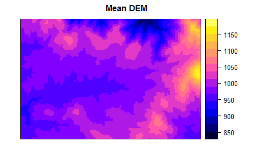

```r
spplot(dem30m, main = list(label = "Mean DEM", cex = 1))
```

```r
summary(dem30m_sd)
```

```
Object of class SpatialGridDataFrame
Coordinates:
       min     max
s1 7394249 7398749
s2 4841999 4844999
Is projected: NA
proj4string : [NA]
Grid attributes:
  cellcentre.offset cellsize cells.dim
x           7394264       30       150
y           4842014       30       100
Data attributes:
  Elevation_sd
 Min.   : 0.1
 1st Qu.: 5.7
 Median : 8.9
 Mean   :11.6
 3rd Qu.:14.8
 Max.   :54.1
```